# Data mining and machine learning

Jake Ryland Williams

June 8th, 2019

# Section 0

## Overview of data mining and machine learning topics

## Overview

1. Introduction and motivation
   1. Classification vs. regression
   2. Supervised vs. unsupervised learning

## Overview

2. Exploratory data analysis
   1. Centrality and Commonality
   2. Dispersion
   3. Extreme behavior

## Overview

3. Clustering
   1. K-means
   2. Hierarchical

## Overview

4. Classification
   1. Naive Bayes
   2. Support Vector Machines
   3. Decision trees and random forests
   4. Accuracy and positive prediction
   5. Precison, recall, and $F_1$

## Overview

5. Regression
   1. Linear and multi-linear regression
   2. Support vector regression regression
   3. Random forest regression

# Section 1

## Introduction and motivation to data analytics

## Introduction

1.1 Classification vs. regression

- Both involve quantitative models that ‘fit’ data,
- i.e., achieve good/best output w/respect to performance.
- But what’s the difference?

> In general, for regression models the output variables take the form of continuous values, and in classification the output variables takes class labels.

## Regression

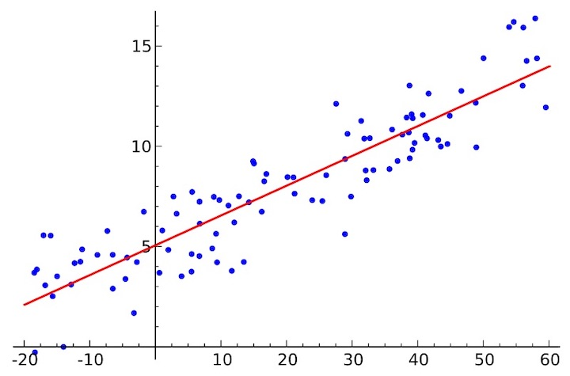

Here, the distances between the point values and output model quantities quantify ‘success’.

## Classification

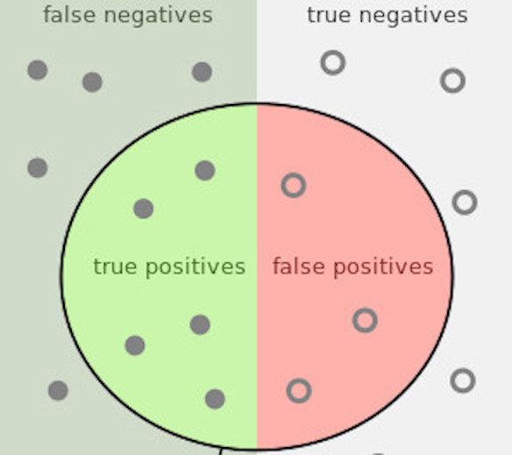

Here, the correctness between the groups and output model labels quantify ‘success’.

## Introduction

1.2 Machine learning

- Adopting a succinct definition of machine learning (ML) from a [blog post](https://www.analyticsvidhya.com/blog/2015/07/difference-machine-learning-statistical-modeling/):

> Machine learning is an algorithm that can learn from data without relying on rules-based programming.
- classification and regression fall into ML.
- This broadness includes many ‘good ideas’ algs.,
- i.e., logical procedures that can be optimized for ‘success’.
- Perhaps we need a more general way of organizing algs.?

## Introduction

1.3 Supervised vs. unsupervised learning

- The question is if some notion of ‘truth’ is known.
- Such data are often called a ‘gold standard’,
- If an algs. optimization uses them, it’s *supervised*,
- and if not, it’s *un-supervised*.
- E.g., clustering (un-superv.) vs. classification (superv.):
  - clusters are predicted groups; no labels are known.

# Section 2

## Exploratory data analysis (EDA)

## EDA

2.1 Looking at data

- It’s easy to dig in, if data are reasonably clean.
- Visually, we can compare numeric data values,
- and with categorical data, we can review occurrence.

## Scatter plot

- Analytics languages make data inspection easy.
- The standard `plot()` is an easily customized scatter plot:

```
iris <- read.csv("./data/iris.csv")
quartz(c(6,6))
jpeg('./fig/petal-length_width.jpg')
plot(iris$petal_length, iris$petal_width,
     pch = 20, cex = 2,
     col = rgb(red = .1, green = .1, blue = .1, alpha = 0.5),
     xlab = 'Petal length', ylab = 'Pedal width',
     main = 'Petal length vs. width')
dev.off()
```

## Scatter plot

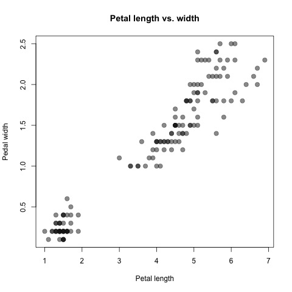

Scatter is the basic plot type, and compares along two numerical aces. Do notice any patterns, just from looking at the data?

## Bar plot

- The `barplot()` makes an easy categorical comparison:

```
webfilter <- read.csv("./data/webfilter.csv")
quartz(c(6,6))
jpeg('./fig/appropriate-sites.jpg')

n_appr = length(webfilter$final_judgment[which(webfilter$final_judgment >= 0)])
barplot(c(n_appr, dim(webfilter)[1] - n_appr),
     ylab = 'Number of sites', names.arg = c('Appropriate','Inappropriate'),
     main = 'Number of sites by content appropriateness')
dev.off()
```

## Bar plot

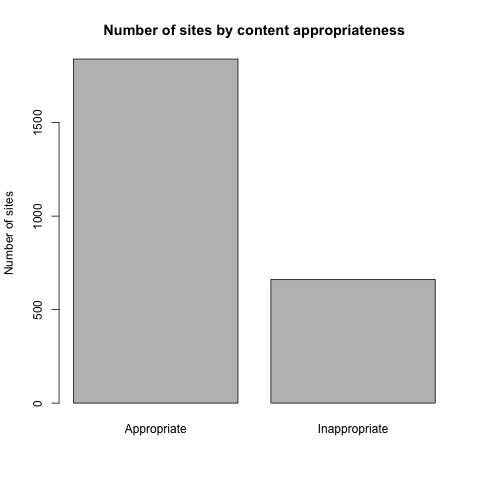

Categories are discrete, but can still have the occurrence compared. What sort of sites are more common and how disproportionate is the balance?

## EDA

2.2 Centrality and commonality

- Commonality refers to how much of something there is.
- To organize, `sort`ing determines least-to-most:

  ```r
  sort(c(12, 5, 19.3, 5, 8, 6, 5))
  ```

  ```
  ## [1]  5.0  5.0  5.0  6.0  8.0 12.0 19.3
  ```

- Relatedly, `order()` produces a rankings:

  ```r
  order(c(12, 5, 19.3, 5, 8, 6, 5))
  ```

  ```
  ## [1] 2 4 7 6 5 1 3
  ```

- that is, the sorting index of least-to-most.

## Centrality

- Centrality refers to numerical data ‘middleness’.
- The arithmetic average (mean) of data is one way:

  ```r
  mean(c(12, 5, 19.3, 5, 8, 6, 5))
  ```

  ```
  ## [1] 8.614286
  ```

- but it’s not robust to ‘outliers’, or extreme points:

  ```r
  mean(c(12000, 5, 19.3, 5, 8, 6, 5))
  ```

  ```
  ## [1] 1721.186
  ```

- unlike the *median*, or sort-central value:

  ```r
  median(c(12000, 5, 19.3, 5, 8, 6, 5))
  ```

  ```
  ## [1] 6
  ```

## Histogram

- A `hist`-ogram bins near points in common,
- which provides insight & backdrop to centrality:

  ```
  iris <- read.csv("./data/iris.csv")
  quartz(c(6,6))
  jpeg('./fig/iris-hist.jpg')

  hist(iris$petal_length,
       col = rgb(red = .1, green = .1, blue = .1, alpha = 0.5),
       ylab = 'Frequency', xlab = 'Petal length',
       main = 'Petal lengths: mean (red) & median (blue)')
  abline(v = mean(iris$petal_length, na.rm = TRUE),
         col = 'red', lwd = 2)
  abline(v = median(iris$petal_length, na.rm = TRUE),
         col = 'blue', lwd = 2)
  dev.off()
  ```

## Histogram

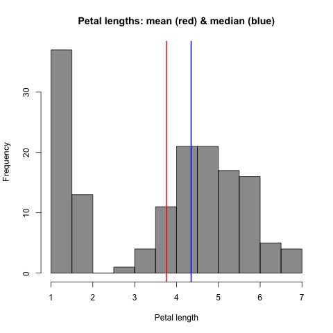

Histogram showing density of iris’ (commonality) and distribution centrality in the mean (red) and median (blue) line positions. Is centrality telling us the whole story here?

## EDA

2.3 Dispersion & extreme behavior

- Dispersion refers to how spread apart things are,
- and median is actually part of a larger concept.
- *Quantiles* are sort-position values by portion,
- e.g., a 25th percentile is larger than 25% of the data:

  ```r
  quantile(c(12, 5, 19.3, 5, 8, 6, 5), probs = c(0.25, 0.5, 0.75))
  ```

  ```
  ## 25% 50% 75%
  ##   5   6  10
  ```

## Variance

- But there’s also an averaging-way to measure dispersion!
- *Variance*, is the average squared mean deviation:
  $$\sigma^2 = \frac{1}{N}\sum_{i = 1}^{N}(\overline{x} - x_i)^2$$
- but to get something more like ‘avg. difference from mean’
- the rooted, *standard deviation*, $\sigma$ is oft used:

  ```r
  var(c(12, 5, 19.3, 5, 8, 6, 5))^0.5
  ```

  ```
  ## [1] 5.354882
  ```

## Extremeness

- Think of $\sigma$ as a scale—ruler—for extremeness,
- or alternatively, the *inter-quartile range (IQR)*,
- measuring the range between 25th and 75th quantiles:

  ```r
  quarts = quantile(c(1, 5, 6, 1, 5, 12, 5, 19, 5, 8, 6, 7, 5),
                    probs = c(0.25,0.75))
  IQR = diff(quarts)
  print(quarts)
  ```

  ```
  ## 25% 75%
  ##   5   7
  ```

  ```r
  print(IQR)
  ```

  ```
  ## 75%
  ##   2
  ```

## Outliers

- Outliers are points that deviate wildly from the middle.
- With $\sigma$ ‘outlier’ points lie $x\sigma$ beyond $\overline{x}$.
- or more than $x$ IQRs from upper/lower quartiles.
- Here’s some (relatively mild) $1.5\sigma$ outliers:

  ```r
  iris <- read.csv("./data/iris.csv")
  pet_len_std = var(iris$petal_length, na.rm = TRUE)^0.5
  mean_outs = which(abs(iris$petal_length - mean(iris$petal_length,
                        na.rm = TRUE)) > 1.5*pet_len_std)
  print(iris$petal_length[mean_outs])
  ```

  ```
  ## [1] 1.1 1.0 6.6 6.7 6.9 6.7
  ```

## Box plot

- *Box plots* visualize centrality, spread, and extremeness.
- The box shows 25th–75th quantiles, crossed by median,
- and whiskers extend up to the extreme points.
- Here, whisker cutoff is set for 0.5-IQR deviants:

  ```
  iris <- read.csv("./data/iris.csv")
  quartz(c(6,6))
  jpeg('./fig/iris-boxplot.jpg')

  boxplot(iris$petal_length, ylab = 'Petal length', range = 0.5,
          main = 'Petal lengths box and whiskers plot')
  dev.off()
  ```

- which makes for a mild definiton of outlier.

## Box plot

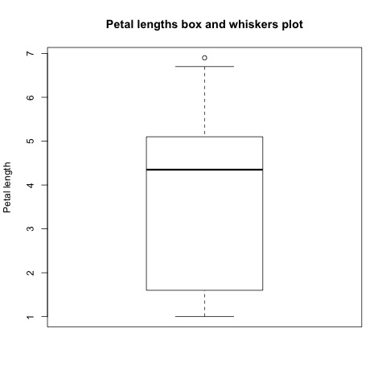

Box plot showing the median and interquartile range, with whiskers extending until the ‘outlier’ definition, here, 0.5 IQR-lengths above/below the IQR. Does anything exhibit strange central tendencies?

# Section 3

## Clustering

## Clustering

- These algorithms group data together with similar values,
- which means we need a notion of ‘similar’.
- Another challenge is selecting the number of clusters.
- Algorithms are generally either ‘flat’ or hierarchical.

## Clustering

3.1 K-means

- This flat-clustering algorithm assumes $K$ clusters,
- for which initial random centers are generated.
- Then iteratively:
  1. each point is assigned to its nearest center
  2. new centers are averaged from the recent assignments
- When clusters stop varying, the algorithm ceases.

## K-means

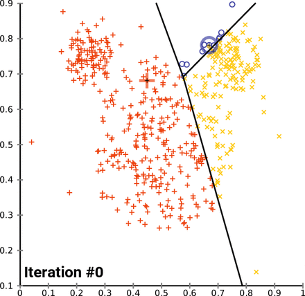

An animation of K-means clustering with 3 clusters; centers slowly stabilize into position.

## K-means

- Running K-means is fairly straightforward:

  ```r
  petals = subset(iris, select=c(petal_length,petal_width))
  km = kmeans(petals, centers=2)
  ```

- are the clusters reasonable?

  ```r
   print(list(km$cluster[c(1:5,51:55)],iris$species[c(1:5,51:55)]))
  ```

  ```
  ## [[1]]
  ##  1  2  3  4  5 51 52 53 54 55
  ##  1  1  1  1  1  2  2  2  2  2
  ##
  ## [[2]]
  ##  [1] setosa     setosa     setosa     setosa     setosa     versicolor
  ##  [7] versicolor versicolor versicolor versicolor
  ## Levels: setosa versicolor virginica
  ```

## K-means

- To visualize output, we might want to color-by cluster:

  ```
  quartz(c(6,6))
  jpeg('./fig/petal-length_width-clusters.jpg')
  clust_1 = which(km$cluster == 1)
  clust_2 = which(km$cluster == 2)
  plot(iris$petal_length, iris$petal_width,
       pch = 20, cex = 2, col = 'white',
       xlab = 'Petal length', ylab = 'Pedal width',
       main = 'Petal length vs. width')
  points(iris$petal_length[clust_1], iris$petal_width[clust_1],
         pch = 20, cex = 2,
         col = rgb(red = 1, green = 0, blue = 0, alpha = 0.5))
  points(iris$petal_length[clust_2], iris$petal_width[clust_2],
         pch = 20, cex = 2,
         col = rgb(red = 0, green = 0, blue = 1, alpha = 0.5))
  points(km$centers[1,1], km$centers[1,2], col = "red", pch = 2, cex = 5)
  points(km$centers[2,1], km$centers[2,2], col = "blue", pch = 5,cex = 5)
  dev.off()
  ```

- and be sure to plot the cluster centers.

## K-means

[figure not shown]

Here two clusters seem to have doen a nice job, but is 2 really the right number? Should we use any other features?

## Clustering

3.2 Hierarchical

- Hierarchical clustering builds a tree of close points.
- All start in their own clusters, and
- closes-clusters are merged iteratively to build up.
- Now, the choice of K is to pick a ‘cut point’.

## Hierarchical clustering

- Again, implementation is straightforward:

  ```r
  # euclidean distance for 'closeness'
  d = dist(petals, method = "euclidean")
  clust_fit = hclust(d, method="ward.D2")
  groups <- cutree(clust_fit, k=2)
  ```

- are the clusters reasonable?

  ```r
  print(list(groups[c(1:5,51:55)],iris$species[c(1:5,51:55)]))
  ```

  ```
  ## [[1]]
  ##  1  2  3  4  5 51 52 53 54 55
  ##  1  1  1  1  1  2  2  2  2  2
  ##
  ## [[2]]
  ##  [1] setosa     setosa     setosa     setosa     setosa     versicolor
  ##  [7] versicolor versicolor versicolor versicolor
  ## Levels: setosa versicolor virginica
  ```

# Section 4

## Classification

## Classification

- These algorithms assign/predict labels according to ‘features’
- which which might be either numberical or categorical.
- A lot of classification is binary, often for simplicity.
- True labels are known and used for training & evaluation,
- which make this into a type of supervised learning.
- Like clustering, classifer quantitative foundations vary.

## Classification

4.1 Naive Bayes

- These [probabilistic classifiers](https://en.wikipedia.org/wiki/Naive_Bayes_classifier) have commonly been used in spam filters.
- They estimate classes as conditional likelihoods
- based on labeled data instances,
- assuming all column-features interact independently.

## Naive Bayes

- Here, we’ll have to first `install.packages('e1071')`.
- Then the process is reasonably straightforward.
- However, the first thing we should always do:
  - split our data into training and test samples:

  ```r
  set.seed(13)
  sample = sample.int(n = nrow(iris),
                      size = floor(.8*nrow(iris)),
                      replace = F)
  train = iris[sample, ]
  test = iris[-sample, ]
  ```

## Naive Bayes

- Once we have our split, the process is smooth:

  ```r
  library(e1071)
  nb_model = naiveBayes(species ~ ., data = train)
  nb_predictions = predict(nb_model, as.data.frame(test)[,1:4])
  list(nb_predictions[1:10],test$species[1:10])
  ```

  ```
  ## [[1]]
  ##  [1] setosa setosa setosa setosa setosa setosa setosa setosa setosa setosa
  ## Levels: setosa versicolor virginica
  ##
  ## [[2]]
  ##  [1] setosa setosa setosa setosa setosa setosa setosa setosa setosa setosa
  ## Levels: setosa versicolor virginica
  ```

## Evaluation

- Let’s check to see which labels we got right:

  ```r
  print(which(nb_predictions != test$species))
  ```

  ```
  ## [1] 24 26
  ```

- This makes it easy to compute accuracy

  ```r
  print(length(which(nb_predictions == test$species))/
        length(test$species))
  ```

  ```
  ## [1] 0.9333333
  ```

## Classification

4.2 Support Vector Machines (SVMs)

- SVMs can be run from the same package (`e1071`).
- These models separate data by widest margens.
- Margins can have arbitrary shapes, e.g., lines,
- with ‘shapes’ defined by *kernel* functions.
- Linear SVMs are just lines separating points.

## SVMs

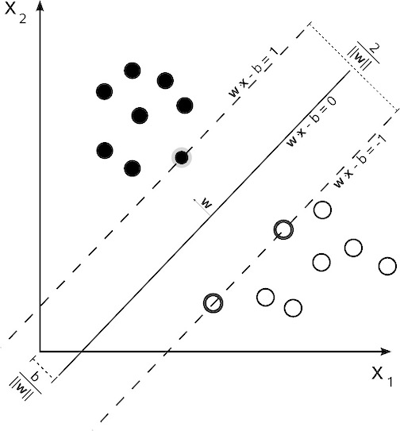

Here, a ‘hyperplane’ is found that separates the data.

## SVMs

- Running an SVM is much the same as NaiveBayes:

  ```r
  svm_model = svm(species ~ ., data = train)
  svm_predictions = predict(svm_model, as.data.frame(test)[,1:4])
  list(svm_predictions[1:10],test$species[1:10])
  ```

  ```
  ## [[1]]
  ##      4     10     12     16     21     24     27     34     44     50
  ## setosa setosa setosa setosa setosa setosa setosa setosa setosa setosa
  ## Levels: setosa versicolor virginica
  ##
  ## [[2]]
  ##  [1] setosa setosa setosa setosa setosa setosa setosa setosa setosa setosa
  ## Levels: setosa versicolor virginica
  ```

## SVMs

- Does the accuracy appear to be any better?

  ```r
  print(which(svm_predictions != test$species))
  ```

  ```
  ## [1] 24 26
  ```

  ```r
  print(length(which(svm_predictions == test$species))/
        length(test$species))
  ```

  ```
  ## [1] 0.9333333
  ```

## Classification

4.4 Decision trees and random forests

- *Decision trees* are another common family.
- These are one-directional flow charts
- with branching points assessing questions.
- Terminal branches are ‘leaves’,
- which are the decisions made by the model:

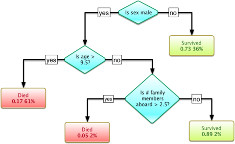

## Decision trees and random forests

- Figuring out questions and ordering is tricky.
- Trees are also rigid, commonly over-fit, and
- Initialization plays a big role in end-models.
- This is why *many* trees are often averaged over,
- which is called *random forest (RF)* modeling.

## Decision trees and random forests

- Implementing RF requires `install.packages('randomForest')`,
- which conveniently works like the `e1071` package:

  ```r
  library(randomForest)
  rf_model = randomForest(species ~ ., data = train)
  rf_predictions = predict(rf_model, as.data.frame(test)[,1:4])
  ```

## Decision trees and random forests

- Does the accuracy appear to be any better?

  ```r
  print(which(rf_predictions != test$species))
  ```

  ```
  ## [1] 24 26
  ```

  ```r
  print(length(which(rf_predictions == test$species))/
        length(test$species))
  ```

  ```
  ## [1] 0.9333333
  ```

## Classification

4.5 Accuracy and positive prediction

- Confusion matrix

## Classification

4.6 Precison, recall, and $F_1$

# Section 5

## Regression

## Regression

5.1 Linear and multi-linear

- Linear regression is a common starting place.
- The goal: use a line to predict a cloud of points.
- But what happens if the data has more than two columns?
- This is *multi-linear regression* more generally,
- and extends the notion of ‘line through a cloud’.

## Linear regression

- Linear regression is a built-in functionality:

  ```r
  lin_mod = lm(iris$petal_length ~ iris$petal_width)
  ```

- and the root mean squared error (RMSE) is an evaluation:

  ```r
  print(mean((iris$petal_length - lin_mod$fitted.values)^2)^0.5)
  ```

  ```
  ## [1] 0.4754497
  ```

## Linear regression

- Visualizing output is a handy check;
- we can build a trained model ‘by hand’:

  ```
  jpeg('./fig/petal-length_width-model.jpg')
  plot(iris$petal_width, iris$petal_length,
       pch = 20, cex = 2,
       col = rgb(red = .1, green = .1, blue = .1, alpha = 0.5),
       xlab = 'Petal width', ylab = 'Pedal length',
       main = 'Petal length vs. width')
  lines(iris$petal_width, lin_mod$fitted.values, col = 'red')
  dev.off()
  ```

## Linear regression

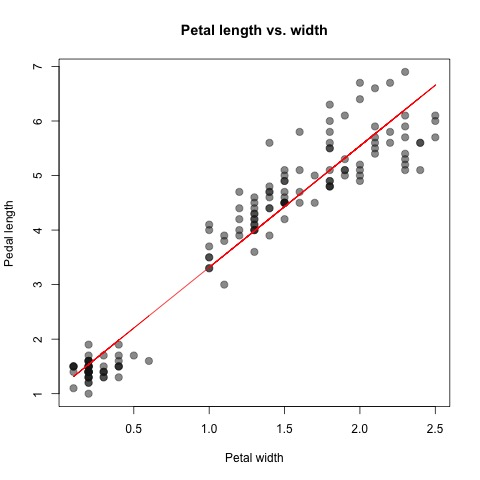

The best-fit line goes through the data, and is supervised to predict the ‘y’ value (petal length) from the ‘x’ value (petal width)

## Linear regression

- To predict from multiple columns, modify the formula

  ```r
  multi_lin_mod = lm(iris$petal_length ~ iris$petal_width
                                       + iris$sepal_length
                                       + iris$sepal_width)
  ```

- Did the evaluation exhibit a ‘better’ model, i.e., less error?

  ```r
  print(mean((iris$petal_length - multi_lin_mod$fitted.values)^2)^0.5)
  ```

  ```
  ## [1] 0.3138365
  ```

## Regression

5.2 Support vector regression regression

- An SVM-like regression can be used, too.
- This is called *support vector Regression (SVR)*:

  ```r
  svm_reg = svm(petal_length ~ petal_width
                             + iris$sepal_length
                             + iris$sepal_width, iris)
  svm_pred = predict(svm_reg, iris)
  ```

- Did the evaluation exhibit a ‘better’ model, i.e., less error?

  ```r
  print(mean((iris$petal_length - svm_pred)^2)^0.5)
  ```

  ```
  ## [1] 0.2426772
  ```

## Regression

5.3 Random forest regression

- As with the others, we can do regression here, too.

  ```r
  rf_reg = randomForest(petal_length ~ petal_width
                                     + iris$sepal_length
                                     + iris$sepal_width, iris)
  rf_pred = predict(rf_reg, iris)
  ```

- Did the evaluation exhibit a ‘better’ model, i.e., less error?

  ```r
  print(mean((iris$petal_length - rf_pred)^2)^0.5)
  ```

  ```
  ## [1] 0.1875419
  ```